# ANOVA in simple regression tree

Jiaying Wu

05/05/2021

In regression, we can use the ANOVA information criterion to find the best split that separate our data points in the head node into two nodes, that is left node and right node.

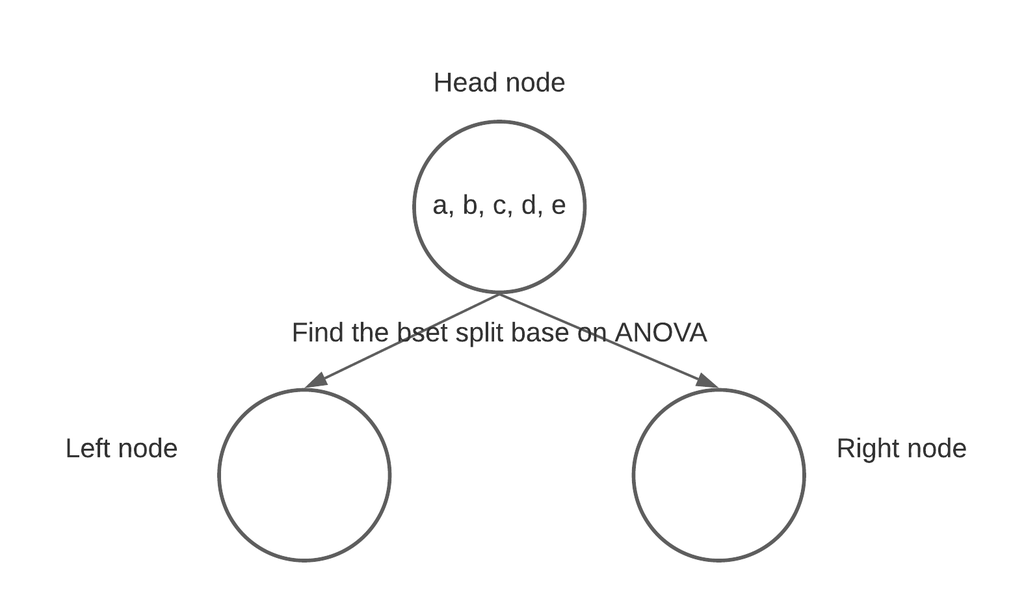

```r
library(tidyverse)
d <- tibble(x = c(1.5, 2.8, 4.1, 2.0, 5.2),
            y = c(6.2, 4.8, 5.1, 7.1, 3.7)) %>%
  mutate(label = c("a", "c", "d", "b", "e"))
d
```

| x | y | label |
| --- | --- | --- |
| 1.5 | 6.2 | a |
| 2.8 | 4.8 | c |
| 4.1 | 5.1 | d |
| 2.0 | 7.1 | b |
| 5.2 | 3.7 | e |

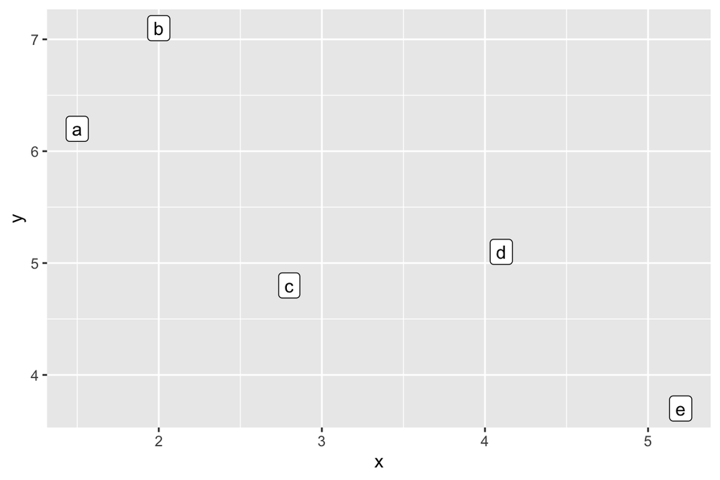

```r
ggplot(data = d, aes(x = x, y = y, label = label)) +
  geom_point() +
  geom_label()
```

The regression tree will go through the point `a` to point `e` base on `x` variable to find the best split in this simple regression tree.

Since the $SST$ is the sum squared residuals of head node, $SSG_1$ is the sum squared residuals of left node and $SSG_2$ is the sum squared residuals of right node. Hence $ANOVA$ is the gain from the split, our goal is to maximize the gain.

Then we write a function to compute the ANOVA base on the index of y. Since the 1.5 is the smallest value of x, the first attempt will be `split_x = 1.5` and calculated the ANOVA. Then the second attempt is `split_x = 2.0`, the attempt will end until `split_x = 4.1`.

```r
# function to compute the ANOVA, the head node contain all the data points to be split
# left node contain the data points that x <= split_x
# right node contain the data points that x > split_x
anova <- function(data, split_x){
  # y in the head node
  hy_mean = mean(data$y)
  # SST of the head node
  sst = sum((data$y - hy_mean)^2)

  # y in the left node
  ly = data$y[which(data$x <= split_x)]
  # the mean of y in the left node
  ly_mean = mean(ly)
  # SSG of the left node
  ssgl = sum((ly - ly_mean)^2)

  # y in the right node
  ry = data$y[which(data$x > split_x)]
  # the mean of y in the right node
  ry_mean = mean(ry)
  # SSG of the right node
  ssgr = sum((ry - ry_mean)^2)

  # ANOVA
  return(sst - (ssgl + ssgr))
}
```

Then we will use for loop to calculate the anova of each attempt

```r
# sort the x, and only use the first 4 x value to split the y
attempt <- tibble(x = sort(d$x)[1:4])
gain_list <- c()

# use the for loop to calculate the gain of each attempt
for(x in attempt$x){
  gain <- anova(d, x)
  gain_list <- c(gain_list, gain)
}

attempt %>%
  mutate(ANOVA = gain_list)
```

| x | ANOVA |
| --- | --- |
| 1.5 | 0.840500 |
| 2.0 | 5.376333 |
| 2.8 | 3.201333 |
| 4.1 | 3.528000 |

Base on the ANOVA value, the ANOVA maximize when we split the data with `x <= 2.0`. `x = 2.0` related to the data point b. Then the data points in the left node will be `a` and `b`, data points in the right node will be `c`, `d` and `e`.

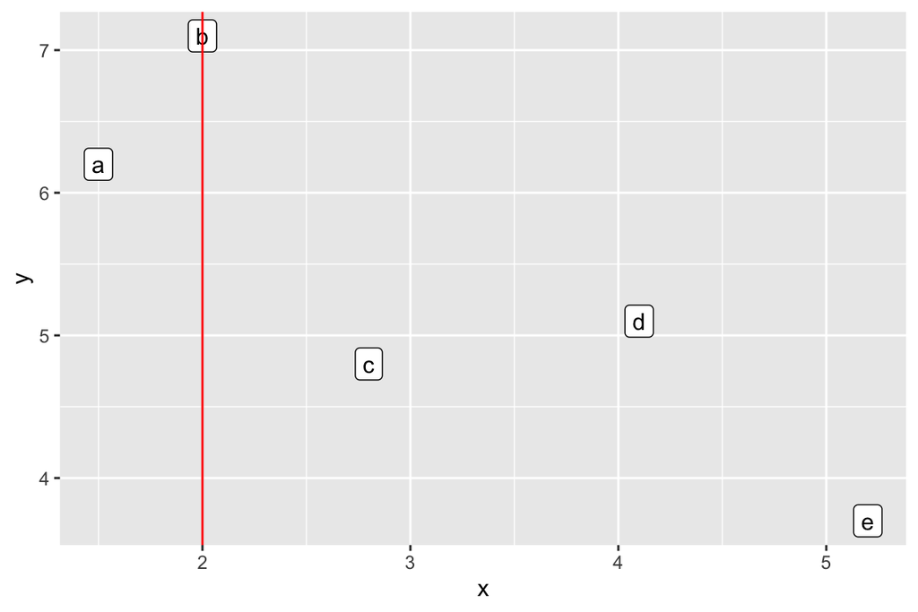

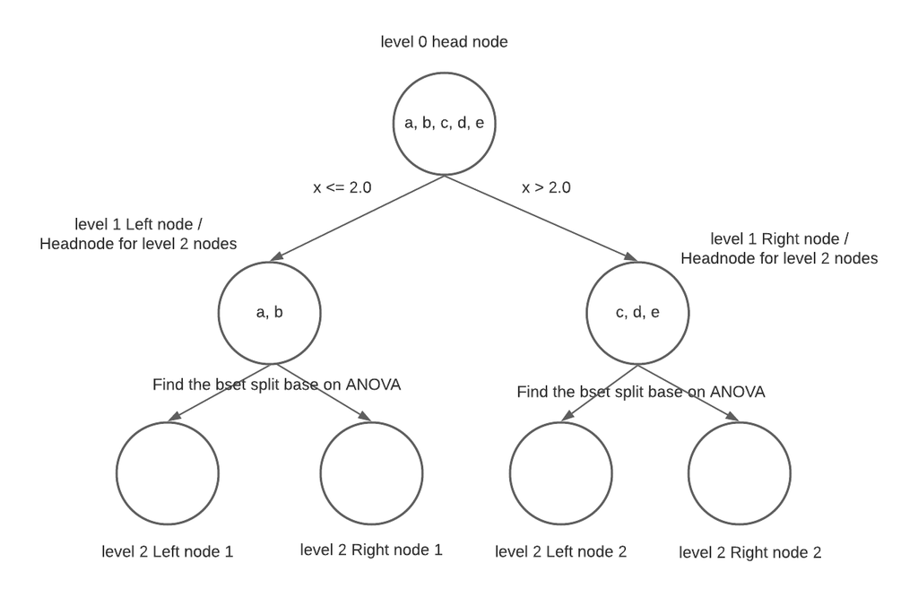

```r
ggplot(data = d, aes(x = x, y = y, label = label)) +
  geom_point() +
  geom_label() +
  geom_vline(xintercept = 2.0, color = "red")
```

The left node and right node in level 1 will become the head node for left nodes and right nodes in level 2. The split will base on the ANOVA value.

For Level 1 left node, we only have one attempt since we only have 2 data points in the head node.

```r
# one attempt for level 1 left node
attempt <- tibble(x = sort(d$x)[1])
# 2 data points in level 1 left node
l1_left_d <- d %>% filter(x <= 2.0)
gain_list <- c()

# use the for loop to calculate the gain of each attempt
for(x in attempt$x){
  gain <- anova(l1_left_d, x)
  gain_list <- c(gain_list, gain)
}

attempt %>%
  mutate(ANOVA = gain_list)
```

| x | ANOVA |
| --- | --- |
| 1.5 | 0.405 |

Since the ANOVA is 0.405, it larger than 0, we split the data point base on `x <= 1.5` in our level 1 left node. Hence, we have point `a` in the `level 2 left node 1`, and point `b` in the `level 2 right node 1`.

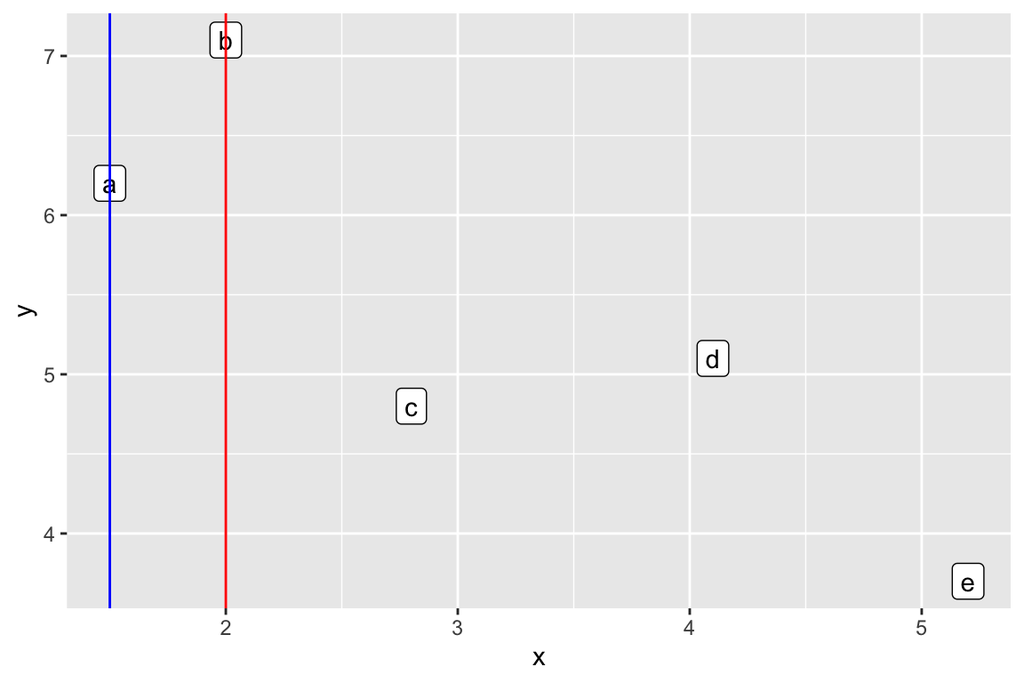

```r
ggplot(data = d, aes(x = x, y = y, label = label)) +
  geom_point() +
  geom_label() +
  geom_vline(xintercept = 2.0, color = "red") +
  geom_vline(xintercept = 1.5, color = "blue")
```

For Level 1 right node, we only 2 attempt since we have 3 data points in the head node.

```r
# 2 attempt for level 1 right node
attempt <- tibble(x = sort(d$x)[3:4])
# 3 data points in level 1 left node
l1_right_d <- d %>% filter(x > 2.0)
gain_list <- c()

# use the for loop to calculate the gain of each attempt
for(x in attempt$x){
  gain <- anova(l1_right_d, x)
  gain_list <- c(gain_list, gain)
}

attempt %>%
  mutate(ANOVA = gain_list)
```

| x | ANOVA |
| --- | --- |
| 2.8 | 0.1066667 |
| 4.1 | 1.0416667 |

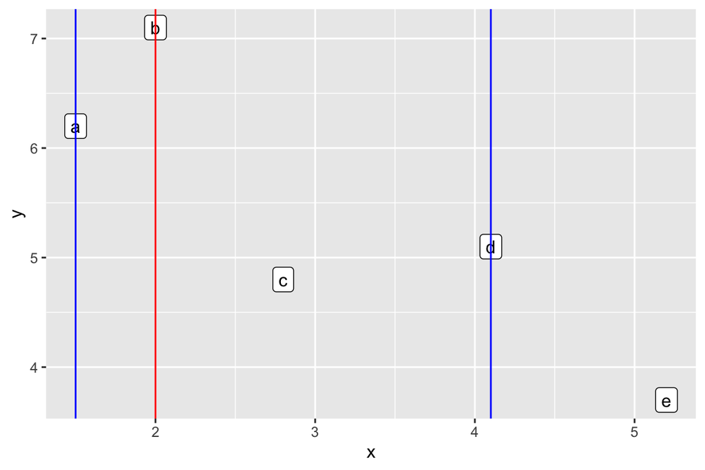

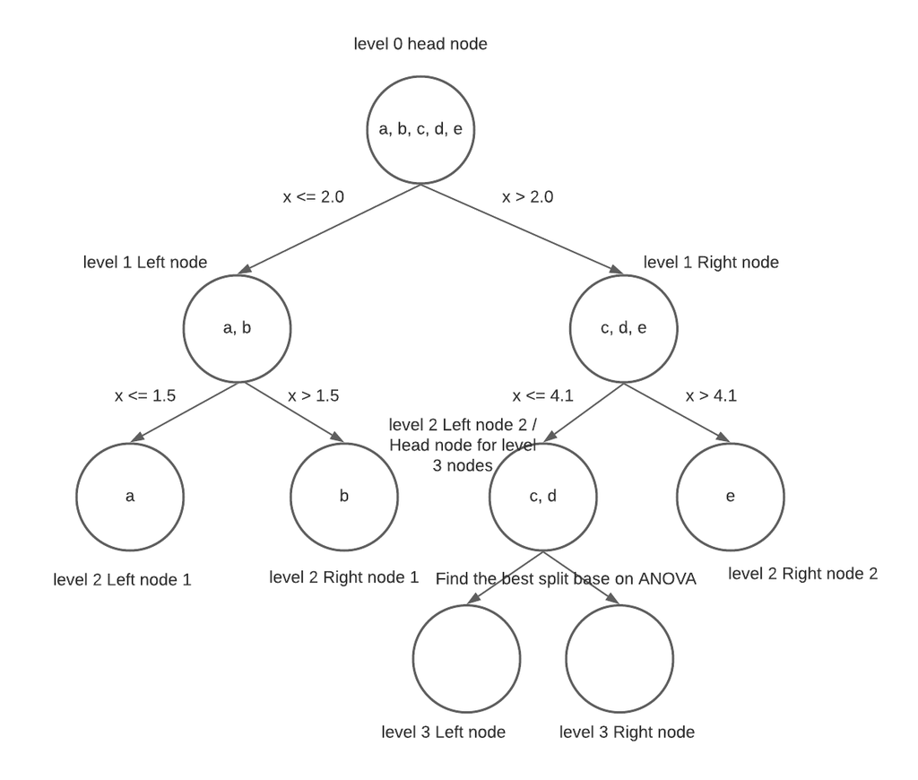

```r
ggplot(data = d, aes(x = x, y = y, label = label)) +
  geom_point() +
  geom_label() +
  geom_vline(xintercept = 2.0, color = "red") +
  geom_vline(xintercept = 1.5, color = "blue") +
  geom_vline(xintercept = 4.1, color = "blue")
```

The level 2 left node 2 become the head node for left node and right node in level 3. The split will base on the ANOVA value.

For Level 2 left node 2, we only have one attempt since we only have 2 data points in the head node.

```r
# one attempt for level 1 left node
attempt <- tibble(x = sort(d$x)[3])
# 2 data points in level 1 left node
l2_left2_d <- l1_right_d %>% filter(x <= 4.1)
gain_list <- c()

# use the for loop to calculate the gain of each attempt
for(x in attempt$x){
  gain <- anova(l2_left2_d, x)
  gain_list <- c(gain_list, gain)
}

attempt %>%
  mutate(ANOVA = gain_list)
```

| x | ANOVA |
| --- | --- |
| 2.8 | 0.045 |

Since the ANOVA is 0.045, it larger than 0, we split the data point base on `x <= 2.8` in our level 2 left node 2. Hence, we have point `c` in the `level 3 left node`, and point `d` in the `level 3 right node`.

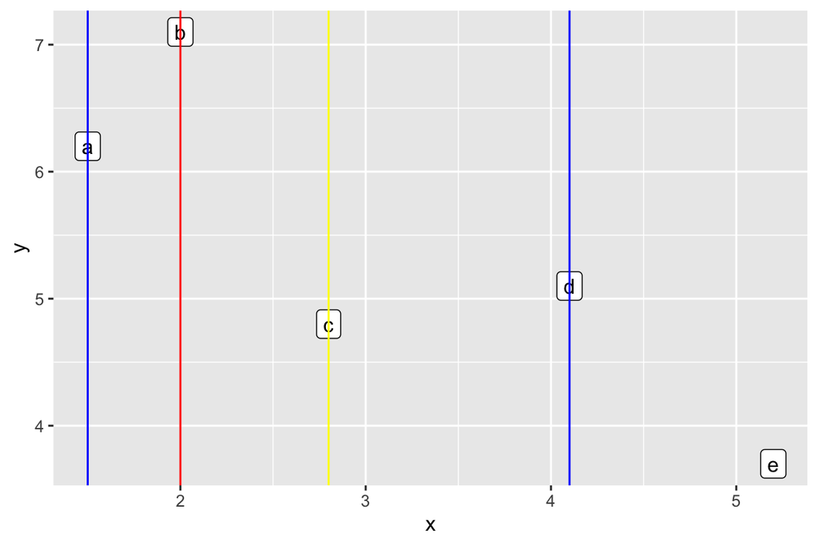

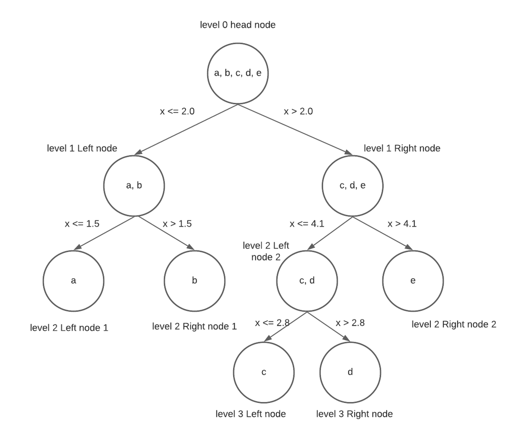

```r
ggplot(data = d, aes(x = x, y = y, label = label)) +
  geom_point() +
  geom_label() +
  geom_vline(xintercept = 2.0, color = "red") +
  geom_vline(xintercept = 1.5, color = "blue") +
  geom_vline(xintercept = 4.1, color = "blue") +
  geom_vline(xintercept = 2.8, color = "yellow")
```